# Regression

## Summary

The goal is to learn how to build and interpret linear regression models using the [mtcars](https://stat.ethz.ch/R-manual/R-devel/library/datasets/html/mtcars.html) data set.

## Methods

These are the statistics we will use to evaluate prediction accuracy for a continuous variable:

- [Mean absolute error](https://en.wikipedia.org/wiki/Mean_absolute_error)
- [Mean squared error](https://en.wikipedia.org/wiki/Mean_squared_error)
- [Root mean squared error](https://en.wikipedia.org/wiki/Root-mean-square_deviation)
- [Mean absolute percentage error](https://en.wikipedia.org/wiki/Mean_absolute_percentage_error)

There are various methods to evaluate and interpret a linear regression model.

- [Adjusted R squared](https://en.wikipedia.org/wiki/Coefficient_of_determination)
- [Variance inflation factor](https://en.wikipedia.org/wiki/Variance_inflation_factor)
- [AIC](https://en.wikipedia.org/wiki/Akaike_information_criterion)
- [BIC](https://en.wikipedia.org/wiki/Bayesian_information_criterion)

Evaluating the distribution of residuals.

- [Cook’s distance](https://en.wikipedia.org/wiki/Cook%27s_distance)
- [Q-Q plot](https://en.wikipedia.org/wiki/Q%E2%80%93Q_plot)
- Heteroscedasticity

Model comparisons.

- [Anova](https://en.wikipedia.org/wiki/Analysis_of_variance)
- k-Fold Cross Validation

## Analysis

### R libraries

We need a couple of libraries for the exercises. Let’s load them all upfront:

```r
library(ggplot2)
library(caret)
library(broom)
library(DMwR)
library(car)
library(leaps)
library(pander)
library(boot)
library(lmtest)
```

### Splitting training and testing data set

We first create a training and testing data set.

```r
set.seed(303)
data(mtcars)
print(head(mtcars))
```

```
##                    mpg cyl disp  hp drat    wt  qsec vs am gear carb
## Mazda RX4         21.0   6  160 110 3.90 2.620 16.46  0  1    4    4
## Mazda RX4 Wag     21.0   6  160 110 3.90 2.875 17.02  0  1    4    4
## Datsun 710        22.8   4  108  93 3.85 2.320 18.61  1  1    4    1
## Hornet 4 Drive    21.4   6  258 110 3.08 3.215 19.44  1  0    3    1
## Hornet Sportabout 18.7   8  360 175 3.15 3.440 17.02  0  0    3    2
## Valiant           18.1   6  225 105 2.76 3.460 20.22  1  0    3    1
```

```r
train = createDataPartition(y = mtcars$mpg, p=0.8, list=F)
training = mtcars[train,]
testing = mtcars[-train,]
print(dim(training))
```

```
## [1] 28 11
```

```r
print(dim(testing))
```

```
## [1]  4 11
```

### Building a linear model

Now let’s build a linear model using one response (outcome) variable, named mpg, and two predictor variables, named wt and disp.

```r
model1 = lm(mpg ~ wt + disp, data=training)
pander(summary(model1))
```

|  | Estimate | Std. Error | t value | Pr(>\|t\|) |
| --- | --- | --- | --- | --- |
| **(Intercept)** | 35.04 | 2.501 | 14.01 | 2.44e-13 |
| **wt** | -3.496 | 1.317 | -2.654 | 0.01362 |
| **disp** | -0.01528 | 0.01028 | -1.487 | 0.1496 |

Fitting linear model: mpg ~ wt + disp

| Observations | Residual Std. Error | $R^2$ | Adjusted $R^2$ |
| --- | --- | --- | --- |
| 28 | 3.001 | 0.7665 | 0.7478 |

### Predict on the testing data

Next, let’s predict on the testing data using our linear model and evaluate the accuracy of the predictions.

```r
pred1 = predict(model1, newdata=testing)
pander(data.frame(prediction=pred1, truth=testing$mpg))
```

|  | prediction | truth |
| --- | --- | --- |
| **Mazda RX4** | 23.43 | 21 |
| **Duster 360** | 17.05 | 14.3 |
| **Dodge Challenger** | 17.87 | 15.5 |
| **Lotus Europa** | 28.29 | 30.4 |

```r
mae = sum(abs(testing$mpg - pred1)) / nrow(testing)
mse = mean((testing$mpg - pred1)^2)
rmse = sqrt(mse)
mape = mean(abs(testing$mpg - pred1) / testing$mpg)
print(c(mae, mse, rmse, mape))
```

```
## [1] 2.4143073 5.8813658 2.4251527 0.1325586
```

```r
DMwR::regr.eval(testing$mpg, pred1)
```

```
##       mae       mse      rmse      mape
## 2.4143073 5.8813658 2.4251527 0.1325586
```

### Interpreting the regression model

There are various methods to evaluate a regression model.

```r
model1 = lm(mpg ~ wt + disp, data=training)
pander(summary(model1))
```

|  | Estimate | Std. Error | t value | Pr(>\|t\|) |
| --- | --- | --- | --- | --- |
| **(Intercept)** | 35.04 | 2.501 | 14.01 | 2.44e-13 |
| **wt** | -3.496 | 1.317 | -2.654 | 0.01362 |
| **disp** | -0.01528 | 0.01028 | -1.487 | 0.1496 |

Fitting linear model: mpg ~ wt + disp

| Observations | Residual Std. Error | $R^2$ | Adjusted $R^2$ |
| --- | --- | --- | --- |
| 28 | 3.001 | 0.7665 | 0.7478 |

```r
print(c(AIC(model1), BIC(model1)))
```

```
## [1] 145.8316 151.1604
```

```r
print(car::vif(model1))
```

```
##       wt     disp
## 5.028637 5.028637
```

The [variance inflation factor](https://en.wikipedia.org/wiki/Variance_inflation_factor) suggests that wt and disp are highly correlated.

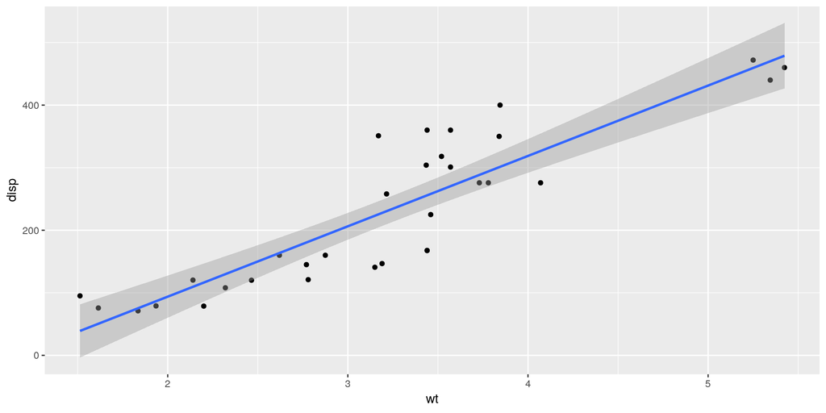

```r
ggplot(data=mtcars, aes(x=wt, y=disp)) + geom_point() + geom_smooth(method="lm")
```

```r
print(cor(mtcars$wt, mtcars$disp))
```

```
## [1] 0.8879799
```

We could try to improve the model by dropping disp and adding qseq

```r
model2 = lm(mpg ~ wt + qsec, data=training)
pander(summary(model2))
```

|  | Estimate | Std. Error | t value | Pr(>\|t\|) |
| --- | --- | --- | --- | --- |
| **(Intercept)** | 19.95 | 5.886 | 3.389 | 0.002329 |
| **wt** | -4.866 | 0.536 | -9.078 | 2.175e-09 |
| **qsec** | 0.89 | 0.2884 | 3.086 | 0.004911 |

Fitting linear model: mpg ~ wt + qsec

| Observations | Residual Std. Error | $R^2$ | Adjusted $R^2$ |
| --- | --- | --- | --- |
| 28 | 2.664 | 0.8159 | 0.8012 |

```r
print(c(AIC(model2), BIC(model2)))
```

```
## [1] 139.1677 144.4965
```

```r
print(car::vif(model2))
```

```
##       wt     qsec
## 1.056561 1.056561
```

Let’s predict on the testing data using model2.

```r
pred2 = predict(model2, newdata=testing)
pander(data.frame(prediction=pred2, truth=testing$mpg))
```

|  | prediction | truth |
| --- | --- | --- |
| **Mazda RX4** | 21.85 | 21 |
| **Duster 360** | 16.67 | 14.3 |
| **Dodge Challenger** | 17.83 | 15.5 |
| **Lotus Europa** | 27.63 | 30.4 |

```r
DMwR::regr.eval(testing$mpg, pred1)
```

```
##       mae       mse      rmse      mape
## 2.4143073 5.8813658 2.4251527 0.1325586
```

```r
DMwR::regr.eval(testing$mpg, pred2)
```

```
##       mae       mse      rmse      mape
## 2.0819012 4.8716207 2.2071748 0.1120204
```

### Analysing Residuals

Let’s check that the residuals scatter around 0 and that there is no apparent bias for larger fitted values.

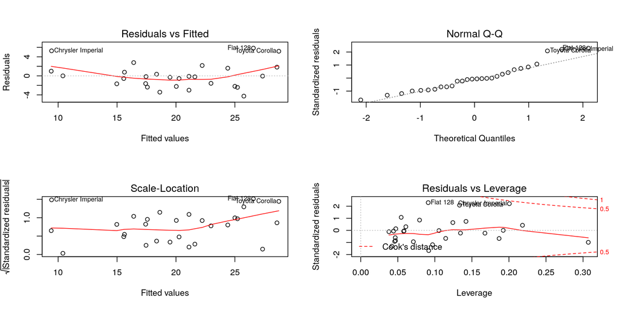

```r
par(mfrow=c(2,2))
plot(model2)
```

```r
lmtest::bptest(model2)
```

```
##
##  studentized Breusch-Pagan test
##
## data:  model2
## BP = 2.8094, df = 2, p-value = 0.2454
```

We can also check if certain data points are extreme.

```r
cooks.distance(model2)
```

```
##       Mazda RX4 Wag          Datsun 710      Hornet 4 Drive
##        3.440706e-05        2.265575e-02        1.286762e-04
##   Hornet Sportabout             Valiant           Merc 240D
##        2.895777e-04        5.041816e-02        2.080759e-02
##            Merc 230            Merc 280           Merc 280C
##        1.454542e-01        1.681455e-04        1.205051e-02
##          Merc 450SE          Merc 450SL         Merc 450SLC
##        1.930343e-03        5.899135e-05        1.331124e-02
##  Cadillac Fleetwood Lincoln Continental   Chrysler Imperial
##        8.217271e-08        1.632744e-02        4.073702e-01
##            Fiat 128         Honda Civic      Toyota Corolla
##        1.758491e-01        3.027824e-02        2.227930e-01
##       Toyota Corona         AMC Javelin          Camaro Z28
##        9.485872e-02        2.524016e-02        1.929933e-02
##    Pontiac Firebird           Fiat X1-9       Porsche 914-2
##        2.230146e-02        1.736129e-05        1.954772e-02
##      Ford Pantera L        Ferrari Dino       Maserati Bora
##        3.508438e-02        2.678358e-03        3.682827e-03
##          Volvo 142E
##        5.957019e-03
```

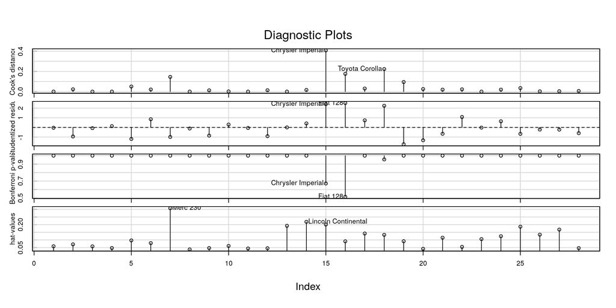

```r
car::influenceIndexPlot(model2)
```

In some cases a log or polynomial transformation of a feature (predictor) variable is required to improve the distribution of residuals.

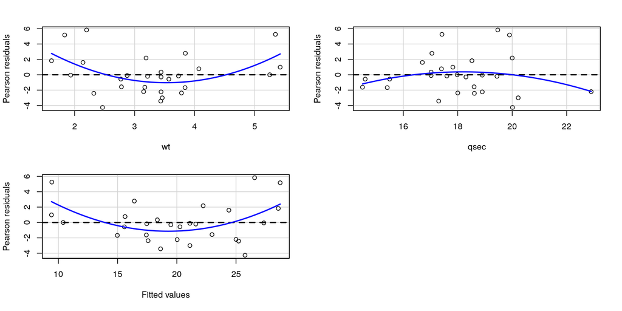

```
##            Test stat Pr(>|Test stat|)
## wt            3.0028         0.006165 **
## qsec         -1.1762         0.251045
## Tukey test    3.1200         0.001809 **
## ---
## Signif. codes:  0 '***' 0.001 '**' 0.01 '*' 0.05 '.' 0.1 ' ' 1
```

```r
car::residualPlots(model2)
```

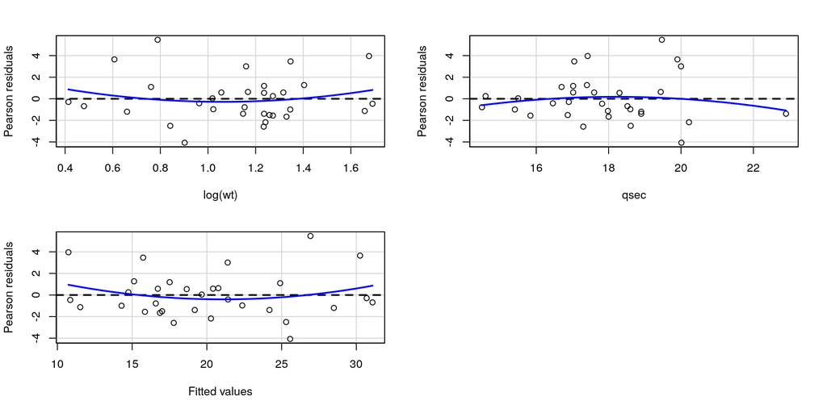

```
##            Test stat Pr(>|Test stat|)
## log(wt)       0.9096           0.3708
## qsec         -0.7045           0.4870
## Tukey test    1.1290           0.2589
```

```r
model3 = lm(mpg ~ log(wt) + qsec, data=mtcars)
car::residualPlots(model3)
```

```r
pander(summary(model3))
```

|  | Estimate | Std. Error | t value | Pr(>\|t\|) |
| --- | --- | --- | --- | --- |
| **(Intercept)** | 22.3 | 4.46 | 4.999 | 2.544e-05 |
| **log(wt)** | -16.18 | 1.252 | -12.92 | 1.465e-13 |
| **qsec** | 0.8932 | 0.2224 | 4.016 | 0.0003835 |

Fitting linear model: mpg ~ log(wt) + qsec

| Observations | Residual Std. Error | $R^2$ | Adjusted $R^2$ |
| --- | --- | --- | --- |
| 32 | 2.177 | 0.878 | 0.8696 |

```r
print(c(AIC(model3), BIC(model3)))
```

```
## [1] 145.4393 151.3023
```

```r
print(car::vif(model3))
```

```
##  log(wt)     qsec
## 1.033693 1.033693
```